# Sensory Data Analysis

Ambu Vijayan

2022-07-28

## Appearance

```
##     consumer product appearance
## 1          1      T1          6
## 2          1      T2          7
## 3          1      T3          6
## 4          1      T4          6
## 5          1      T5          3
## 6          1      T6          7
## 7          1      T7          6
## 8          1      T8          3
## 9          1      T9          7
## 10         1     T10          9
## 11         2      T1          6
## 12         2      T2          6
## 13         2      T3          2
## 14         2      T4          2
```

[output cut: 136 more lines]

### This data set consists of 10 product types assessed by 15 consumers, each row corresponding to the assessment of one product by one consumer.

Representation of the hedonic scores per product, using the boxplot function

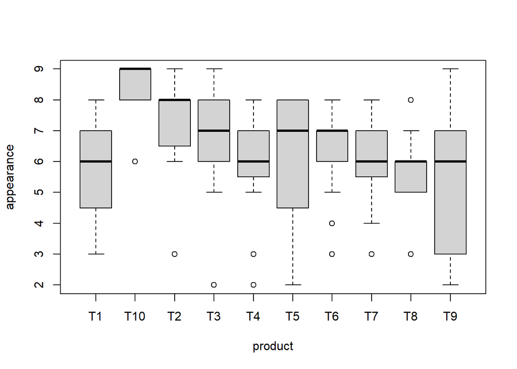

Summary of the Data

```
##     consumer     product     appearance
##  1      :10   T1     :15   Min.   :2.000
##  2      :10   T10    :15   1st Qu.:5.000
##  3      :10   T2     :15   Median :7.000
##  4      :10   T3     :15   Mean   :6.327
##  5      :10   T4     :15   3rd Qu.:8.000
##  6      :10   T5     :15   Max.   :9.000
##  (Other):90   (Other):60
```

As shown by the outputs of the summary function, this data set needs to be restructured.

The new Matrix data would be :

```
##    T1 T10 T2 T3 T4 T5 T6 T7 T8 T9
## 1   6   9  7  6  6  3  7  6  3  7
## 2   6   8  6  2  2  8  3  5  5  7
## 3   4   8  9  9  8  2  7  3  7  9
## 4   3   9  3  7  6  7  7  7  5  8
## 5   7   9  8  8  8  8  6  7  6  6
## 6   4   9  8  2  3  4  5  4  6  2
## 7   5   9  8  7  5  5  6  6  5  4
## 8   7   9  8  5  6  5  6  7  7  7
## 9   5   6  7  7  6  8  8  5  5  6
## 10  5   9  6  6  6  5  6  7  6  6
## 11  8   8  9  7  6  4  7  6  8  3
## 12  8   9  9  8  5  8  8  8  6  2
## 13  8   8  8  8  7  7  7  6  6  2
## 14  3   8  7  7  7  8  8  8  5  8
## 15  7   9  6  8  7  8  4  6  6  3
```

Let’s represent the consumers according to the first point of view. we apply a PCA on this table. Let us remind that for this PCA, two consumers are all the more close that they gave the same scores to the products. For instance, if we consider the following consumers 12, 13, and 4, we expect to find the first two really close on the first factorial plane, and very far from the third one.

```
##    T1 T10 T2 T3 T4 T5 T6 T7 T8 T9
## 12  8   9  9  8  5  8  8  8  6  2
## 13  8   8  8  8  7  7  7  6  6  2
## 4   3   9  3  7  6  7  7  7  5  8
```

Applying and Visualising PCA

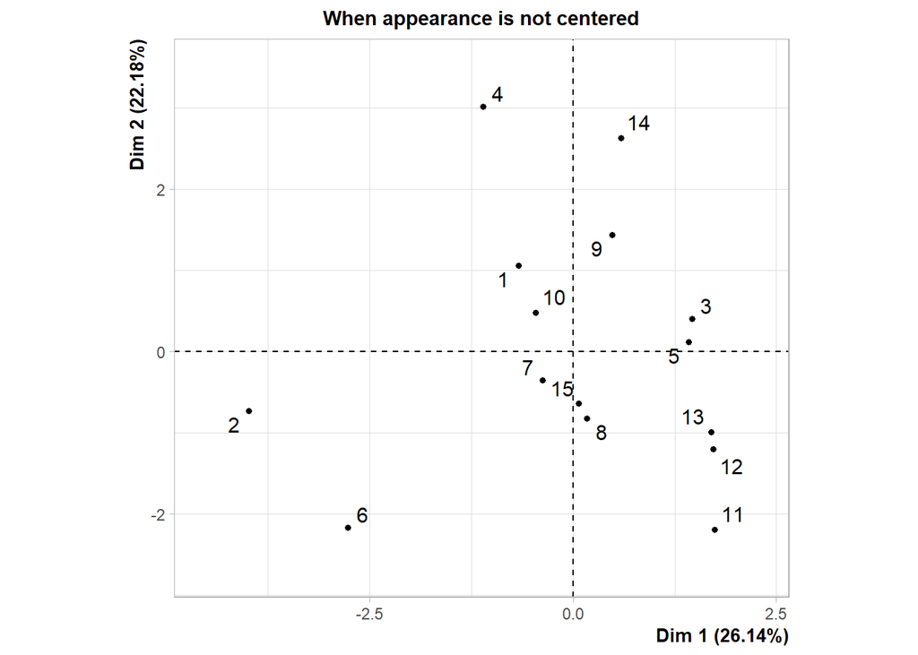

From this analysis, the most surprising results are provided by the variable representation which highlights the size effect.

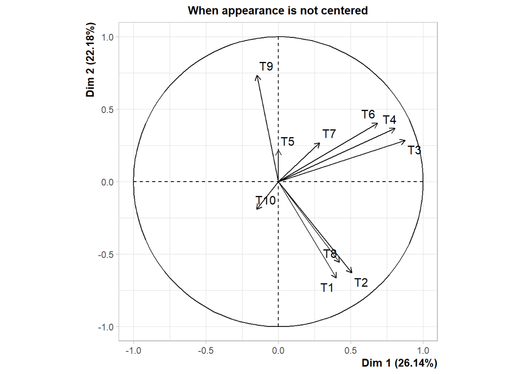

This size effect highlights the fact that the variables of the data set are all positively correlated. In terms of consumers and liking, it means that some consumers like everything, and some others dislike everything.

Let’s now consider the shape effect for which the data set is mean centered by rows, i.e., the data we are dealing with are not pure liking scores anymore, but preferences.

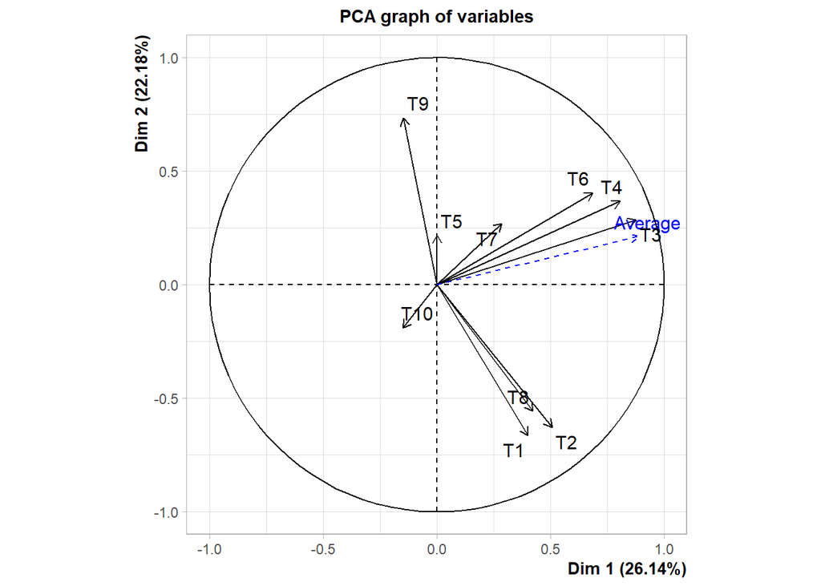

Centering the data by Rows

```
##   1   2   3   4   5   6   7   8   9  10  11  12  13  14  15
## 6.0 5.2 6.6 6.2 7.3 4.7 6.0 6.7 6.3 6.2 6.6 7.1 6.7 6.9 6.4
```

```
##  1  2  3  4  5  6  7  8  9 10 11 12 13 14 15
##  0  0  0  0  0  0  0  0  0  0  0  0  0  0  0
```

Applying and Visualising PCA

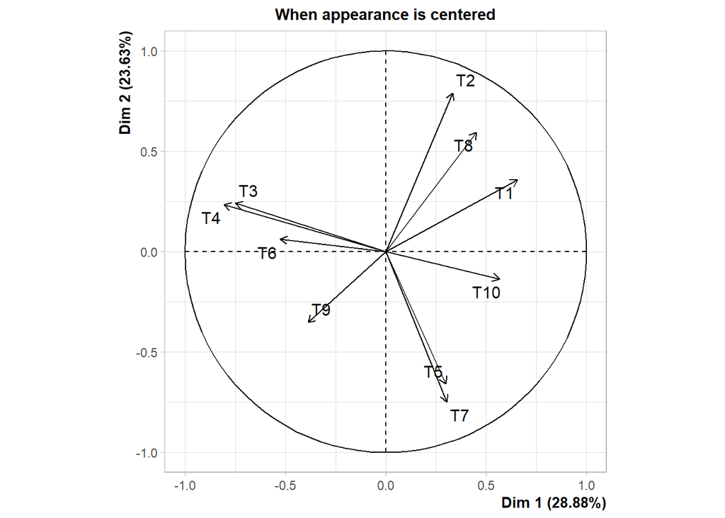

To identify the best product, two different approaches are considered: a univariate and a multivariate one which uses Fisher’s LSD and MDPref respectively.

## Lets consider univariate point of view.

After changing the contrasts in R using the options function, let’s run a two-way ANOVA on the data set

```
## Analysis of Variance Table
##
## Response: appearance
##            Df Sum Sq Mean Sq F value   Pr(>F)
## product     9 113.39 12.5993  4.6567 2.47e-05 ***
## consumer   14  64.69  4.6210  1.7079  0.06174 .
## Residuals 126 340.91  2.7056
## ---
## Signif. codes:  0 '***' 0.001 '**' 0.01 '*' 0.05 '.' 0.1 ' ' 1
```

Summary of the ANOVA

```
##
## Call:
## lm(formula = appearance ~ product + consumer, data = appearance)
##
## Residuals:
##     Min      1Q  Median      3Q     Max
## -4.2733 -0.7067  0.2600  0.9933  3.3933
##
## Coefficients:
##              Estimate Std. Error t value Pr(>|t|)
## (Intercept)  6.326667   0.134303  47.107  < 2e-16 ***
## product1    -0.593333   0.402910  -1.473  0.14335
## product2     2.140000   0.402910   5.311 4.76e-07 ***
## product3     0.940000   0.402910   2.333  0.02123 *
## product4     0.140000   0.402910   0.347  0.72882
## product5    -0.460000   0.402910  -1.142  0.25575
## product6    -0.326667   0.402910  -0.811  0.41903
## product7     0.006667   0.402910   0.017  0.98682
## product8    -0.260000   0.402910  -0.645  0.51990
## product9    -0.593333   0.402910  -1.473  0.14335
## consumer1   -0.326667   0.502517  -0.650  0.51684
## consumer2   -1.126667   0.502517  -2.242  0.02671 *
## consumer3    0.273333   0.502517   0.544  0.58745
## consumer4   -0.126667   0.502517  -0.252  0.80140
## consumer5    0.973333   0.502517   1.937  0.05499 .
## consumer6   -1.626667   0.502517  -3.237  0.00154 **
## consumer7   -0.326667   0.502517  -0.650  0.51684
## consumer8    0.373333   0.502517   0.743  0.45891
## consumer9   -0.026667   0.502517  -0.053  0.95776
## consumer10  -0.126667   0.502517  -0.252  0.80140
## consumer11   0.273333   0.502517   0.544  0.58745
## consumer12   0.773333   0.502517   1.539  0.12633
## consumer13   0.373333   0.502517   0.743  0.45891
## consumer14   0.573333   0.502517   1.141  0.25607
## ---
## Signif. codes:  0 '***' 0.001 '**' 0.01 '*' 0.05 '.' 0.1 ' ' 1
##
## Residual standard error: 1.645 on 126 degrees of freedom
## Multiple R-squared:  0.3431, Adjusted R-squared:  0.2232
## F-statistic: 2.862 on 23 and 126 DF,  p-value: 9.768e-05
```

Lets see how the levels of the Product effect are organized.

```
##  [1] "T1"  "T10" "T2"  "T3"  "T4"  "T5"  "T6"  "T7"  "T8"  "T9"
```

According to the previous outputs, **we can say that T10 and T2 were the most appreciated products**.

## Performing posteriori tests

The LSD.test function returns 5 main outputs

```
## [1] "statistics" "parameters" "means"      "comparison" "groups"
```

Analysing the Statistics output

```
##    MSerror  Df     Mean       CV  t.value      LSD
##   2.705608 126 6.326667 25.99905 1.978971 1.188615
```

the last value provided is called LSD. This corresponds to the least significant difference required between two products to be significantly different. Since here, the LSD value is of 1.19, every pair of products with a difference in the average liking score larger than 1.19 is significant at 5%.

```
##     appearance groups
## T10   8.466667      a
## T2    7.266667      b
## T3    6.466667     bc
## T6    6.333333     bc
## T7    6.066667      c
## T5    6.000000      c
## T4    5.866667      c
## T1    5.733333      c
## T8    5.733333      c
## T9    5.333333      c
```

Graphical representation of the result.

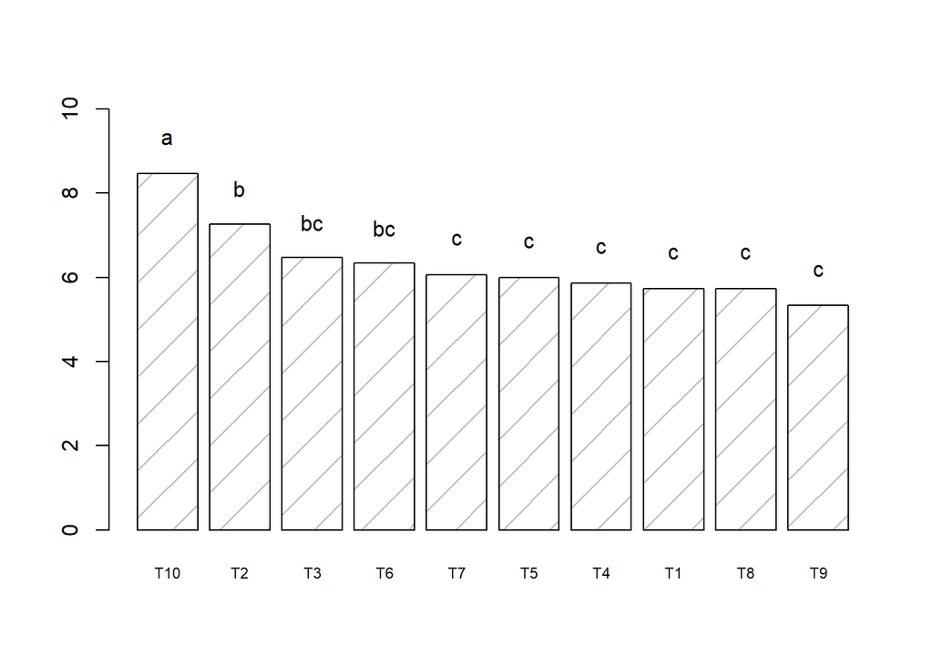

## Lets consider multivariate point of view.

The idea of MDPref, is to get a representation of the products based on the hedonic scores: two products are all the more close that they are liked similarly.

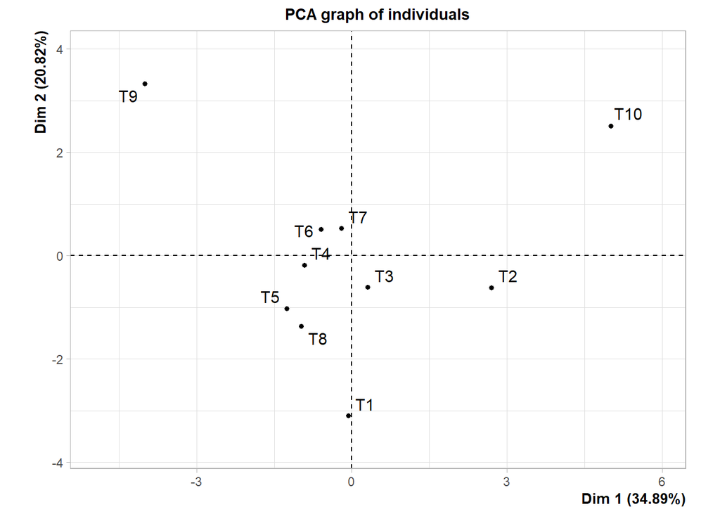

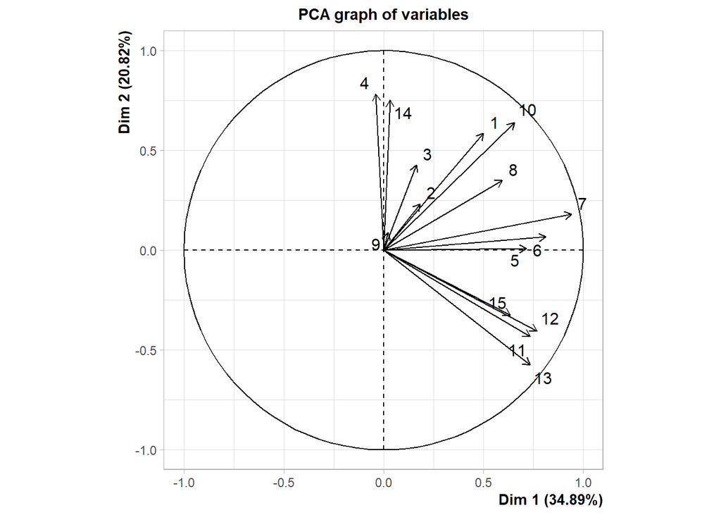

Obtaining groups of products similar in terms of the way they have been preferred

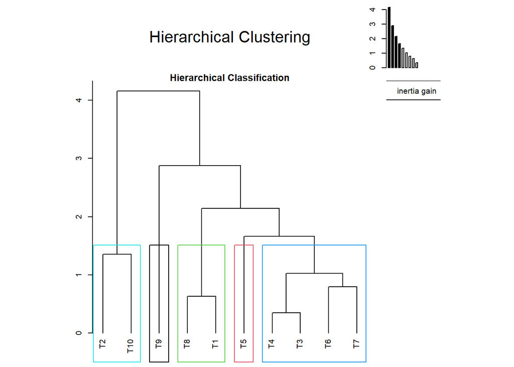

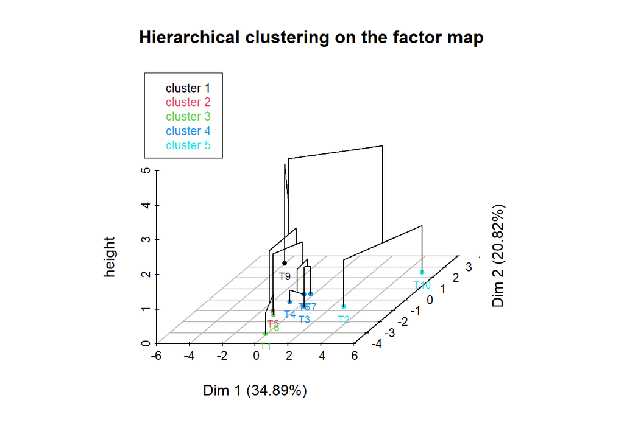

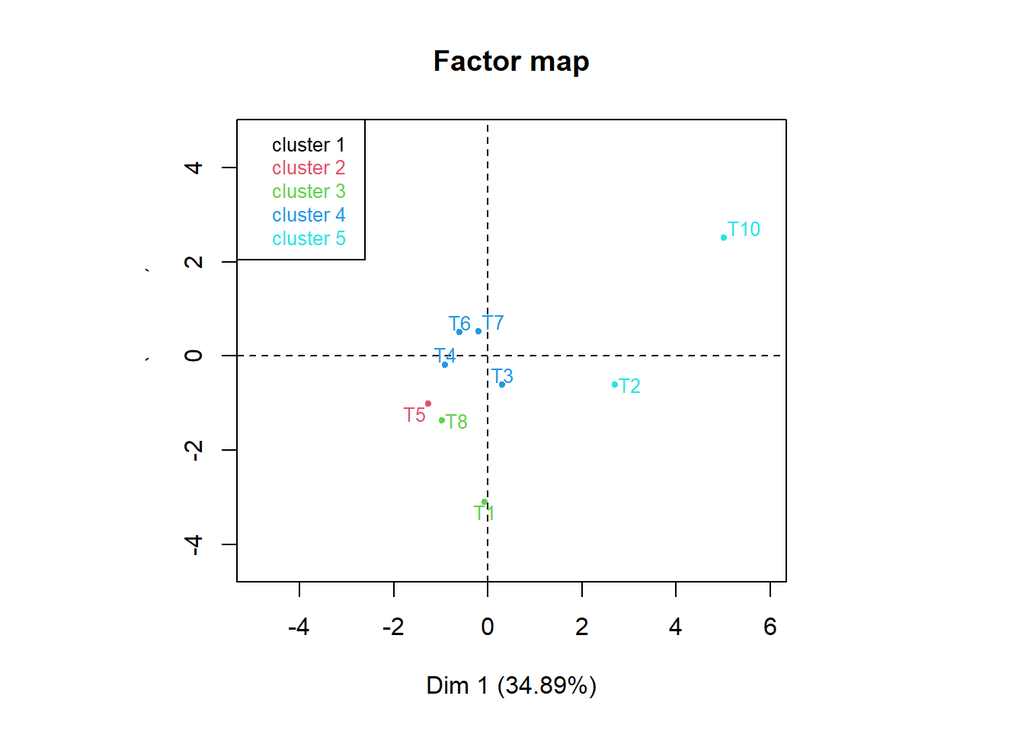

Determining the best product within homogeneous segments of consumers.

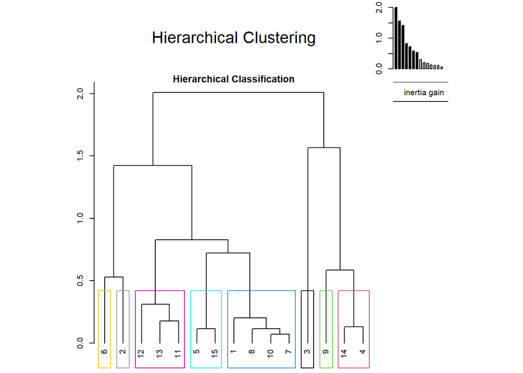

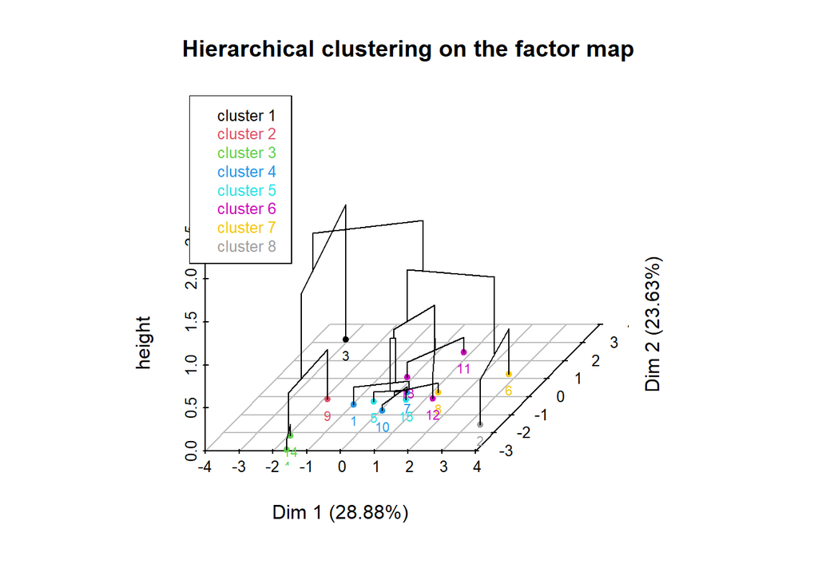

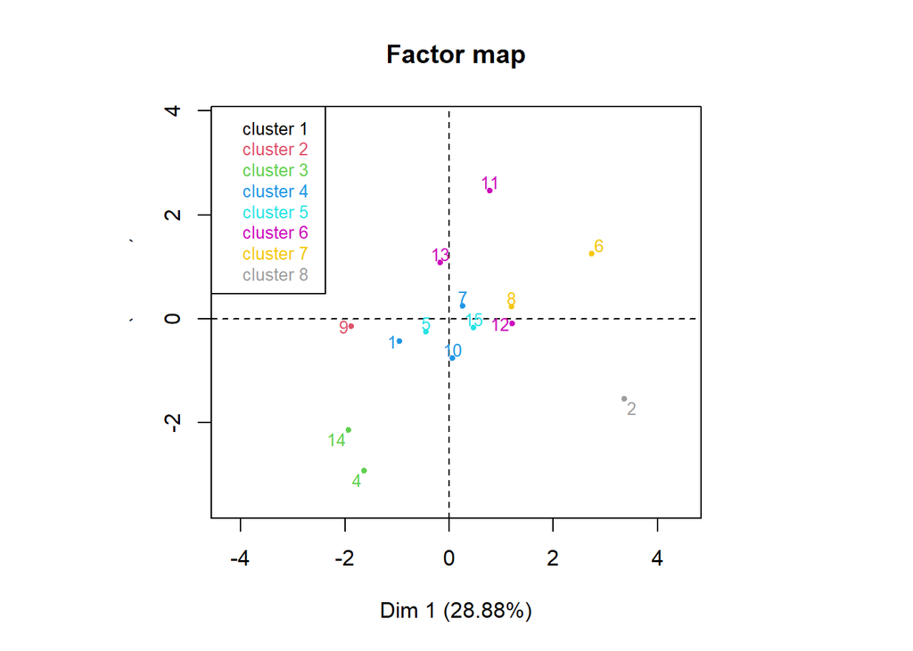

Description of the groups by both the individuals and the variables of the data set.

```
## [1] "data.clust" "desc.var"   "desc.axes"  "desc.ind"   "call"
```

The number of consumers belonging to each group

```
##        T1               T10              T2              T3
##  Min.   :-3.9000   Min.   :-0.30   Min.   :-3.20   Min.   :-3.20
##  1st Qu.:-1.2500   1st Qu.: 1.40   1st Qu.: 0.40   1st Qu.:-0.10
##  Median :-0.3000   Median : 2.30   Median : 1.00   Median : 0.70
##  Mean   :-0.5933   Mean   : 2.14   Mean   : 0.94   Mean   : 0.14
##  3rd Qu.: 0.7000   3rd Qu.: 2.80   3rd Qu.: 1.95   3rd Qu.: 0.95
##  Max.   : 1.4000   Max.   : 4.30   Max.   : 3.30   Max.   : 2.40
##
##        T4              T5                T6                  T7
##  Min.   :-3.20   Min.   :-4.6000   Min.   :-2.400000   Min.   :-3.60
##  1st Qu.:-0.85   1st Qu.:-1.4500   1st Qu.:-0.450000   1st Qu.:-0.65
##  Median :-0.20   Median : 0.3000   Median : 0.300000   Median :-0.20
##  Mean   :-0.46   Mean   :-0.3267   Mean   : 0.006667   Mean   :-0.26
##  3rd Qu.: 0.20   3rd Qu.: 1.0000   3rd Qu.: 0.850000   3rd Qu.: 0.55
##  Max.   : 1.40   Max.   : 2.8000   Max.   : 1.700000   Max.   : 1.10
##
##        T8                T9              clust
##  Min.   :-3.0000   Min.   :-5.1000   4      :3
##  1st Qu.:-1.2500   1st Qu.:-3.0500   6      :3
##  Median :-0.7000   Median :-0.3000   3      :2
##  Mean   :-0.5933   Mean   :-0.9933   5      :2
##  3rd Qu.: 0.0500   3rd Qu.: 1.0500   7      :2
##  Max.   : 1.4000   Max.   : 2.4000   1      :1
##                                      (Other):2
```

According to this output, there are eight groups of consumers, a first one with 1 consumer, a second one with 1 consumers, a third one with 2 consumers and so on.

Description of the first cluster of consumers with respect to the quantitative variables of the data set

```
##    v.test Mean in category Overall mean sd in category Overall sd p.value
## T5 -2.179             -4.6       -0.327              0      1.961   0.029
## T7 -2.995             -3.6       -0.260              0      1.115   0.003
```

```
## $para
## Cluster: 1
##  3
##  0
## ------------------------------------------------------------
## Cluster: 2
##  9
##  0
## ------------------------------------------------------------
## Cluster: 3
##         4        14
## 0.9879192 0.9879192
## ------------------------------------------------------------
## Cluster: 4
##         7        10         1
## 0.8899623 0.8968177 1.0624395
## ------------------------------------------------------------
## Cluster: 5
##         5        15
## 0.9179743 0.9179743
## ------------------------------------------------------------
## Cluster: 6
##       13       11       12
## 1.188335 1.663392 1.758717
## ------------------------------------------------------------
## Cluster: 7
##        6        8
## 1.151747 1.151747
## ------------------------------------------------------------
## Cluster: 8
##  2
##  0
##
## $dist
## Cluster: 1
##        3
## 5.167895
## ------------------------------------------------------------
## Cluster: 2
##        9
```

[output cut: 10 more lines]

```
## Cluster: 5
##       15        5
## 3.548557 2.388242
## ------------------------------------------------------------
## Cluster: 6
##       12       11       13
## 3.248999 2.858395 2.475227
## ------------------------------------------------------------
## Cluster: 7
##        6        8
## 3.687580 2.009112
## ------------------------------------------------------------
## Cluster: 8
##        2
## 3.505905
```

a description of the clusters with respect to the individuals of the data set, from the most typical to the least typical.

The average score by product for each cluster of consumers

```
##     T1  T10   T2   T3   T4   T5   T6   T7   T8   T9
## 1 4.00 8.00 9.00 9.00 8.00 2.00 7.00 3.00 7.00 9.00
## 2 5.00 6.00 7.00 7.00 6.00 8.00 8.00 5.00 5.00 6.00
## 3 3.00 8.50 5.00 7.00 6.50 7.50 7.50 7.50 5.00 8.00
## 4 5.33 9.00 7.00 6.33 5.67 4.33 6.33 6.33 4.67 5.67
## 5 7.00 9.00 7.00 8.00 7.50 8.00 5.00 6.50 6.00 4.50
## 6 8.00 8.33 8.67 7.67 6.00 6.33 7.33 6.67 6.67 2.33
## 7 5.50 9.00 8.00 3.50 4.50 4.50 5.50 5.50 6.50 4.50
## 8 6.00 8.00 6.00 2.00 2.00 8.00 3.00 5.00 5.00 7.00
```

Representing graphically the differences in terms of liking between clusters.

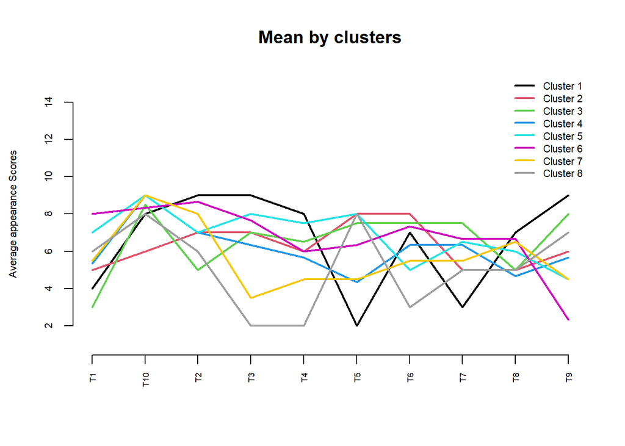

Preffered product of Cluster 1: T2

Preffered product of Cluster 2: T5

Preffered product of Cluster 3: T10

Preffered product of Cluster 4: T10

Preffered product of Cluster 5: T10

Preffered product of Cluster 6: T2

Preffered product of Cluster 7: T10